# Coding Assignment 2 (Part II)

Fall 2021

```r
library(glmnet)
library(pls)
set.seed(100) # change the seed to be the last 4-dig of your UIN
```

## Data Preparation

```r
myData = read.csv("~/Desktop/BostonData2.csv")
myData = myData[, -1]
dim(myData)
```

```
[1] 506  92
```

```r
#names(myData)
```

Some algorithms need the matrix/vector input (instead of a data frame)

```r
X = data.matrix(myData[,-1])
Y = myData[,1]
```

We will repeat the following simulation 50 times. In each iteration, randomly split the data into two parts, 75% for training and 25% for testing.

You can write a loop with 50 iterations, and in each iteration, split the data and run the seven procedures (six procedures for `BostonData3.csv`).

Or you can save the row IDs for the 50 test datasets, then write a separate loop for each method. Using `all.test.id` (produced below), you can ensure that you use the same training/test split for each procedure.

```r
T = 50
n = length(Y)
ntest = round(n * 0.25)  # test set size
ntrain = n - ntest  # training set size
all.test.id = matrix(0, ntest, T)  #
for(t in 1:T){
  all.test.id[, t] = sample(1:n, ntest)
}
#save(all.test.id, file="alltestID.RData")
```

## Seven Procedures

Run the seven procedures and save the results in `MSPE`.

```r
test.id = all.test.id[,1]

MSPE = rep(0, 7)
names(MSPE) = c("Full", "R_min", "R_1se", "L_min", "L_1se", "L_Refit", "PCR")
```

### Full Model

```r
full.model = lm(Y ~ ., data = myData[-test.id,])
Ytest.pred = predict(full.model, newdata = myData[test.id,])
MSPE[1] = mean((myData$Y[test.id] - Ytest.pred)^2)
```

### Ridge

Ridge with lambda.min and lambda.1se

```r
cv.out = cv.glmnet(X[-test.id, ], Y[-test.id], alpha = 0)
best.lam = cv.out$lambda.min
Ytest.pred = predict(cv.out, s = best.lam, newx = X[test.id, ])
MSPE[2] = mean((Y[test.id] - Ytest.pred)^2)
```

The output below is zero, which means that `best.lam` is the smallest lambda value in the default lambda sequence used by `cv.glmnet`. If so, we need to include some lambda values that are smaller than `best.lam` in order to see the U shape CV plot.

```r
sum(cv.out$lambda < best.lam)
```

```
[1] 0
```

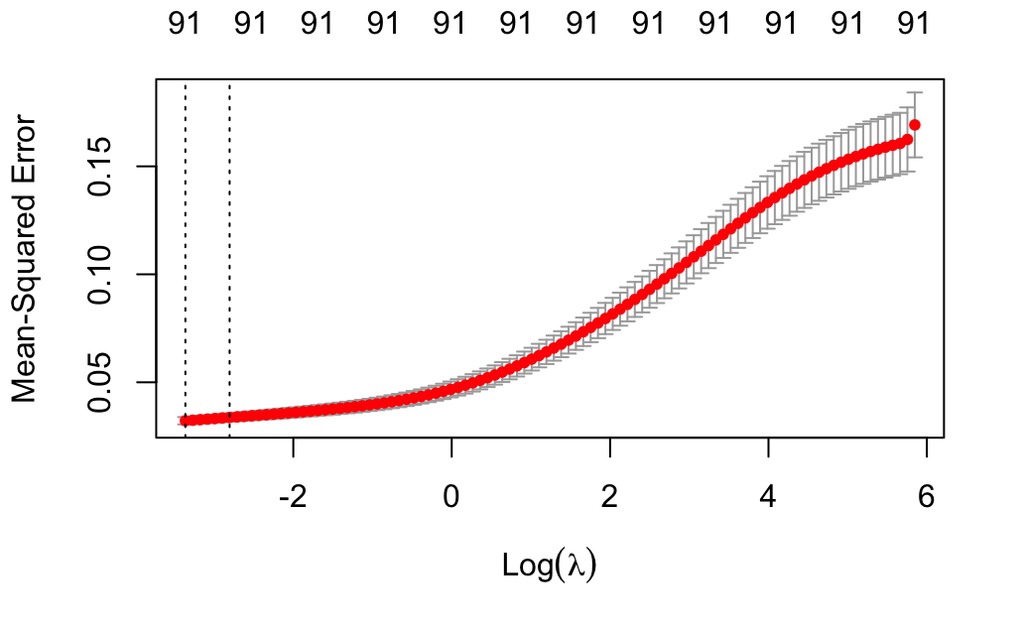

```r
plot(cv.out)
```

Based on the CV plot, we provide a new lambda sequence as follows.

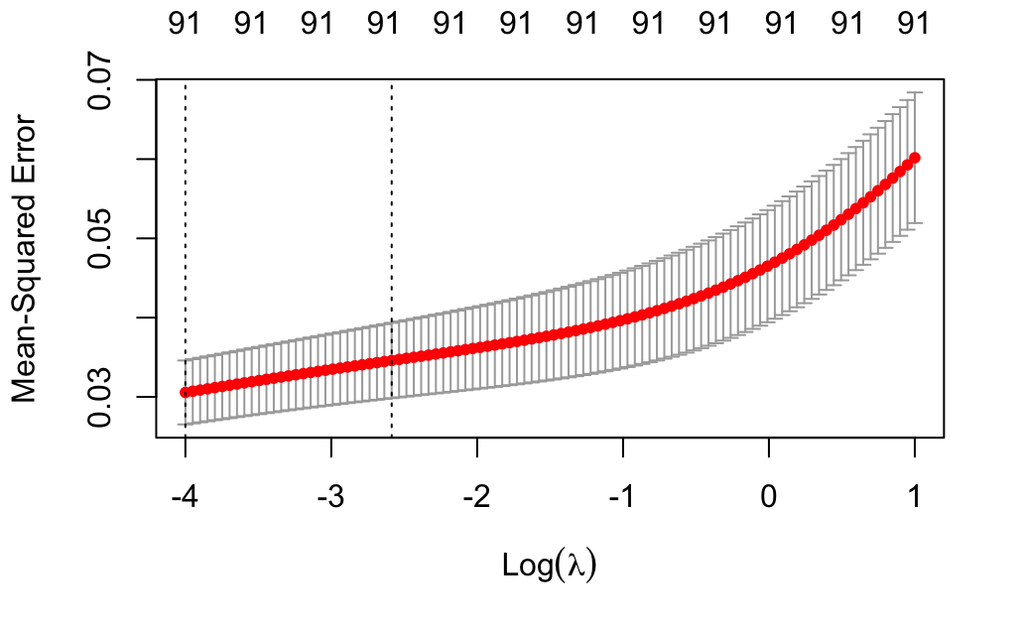

```r
mylasso.lambda.seq = exp(seq(-4, 1, length.out = 100))
cv.out = cv.glmnet(X[-test.id, ], Y[-test.id], alpha = 0,
                   lambda = mylasso.lambda.seq)
plot(cv.out)
```

Based on the CV plot, we have to keep decreasing lambda values. Eventually, we use the following lambda sequence.

```r
mylasso.lambda.seq = exp(seq(-10, -2, length.out = 100))
cv.out = cv.glmnet(X[-test.id, ], Y[-test.id], alpha = 0,
                   lambda = mylasso.lambda.seq)
best.lam = cv.out$lambda.min
Ytest.pred = predict(cv.out, s = best.lam, newx = X[test.id, ])
MSPE[2] = mean((Y[test.id] - Ytest.pred)^2)

best.lam = cv.out$lambda.1se
Ytest.pred = predict(cv.out, s = best.lam, newx = X[test.id, ])
MSPE[3] = mean((Y[test.id] - Ytest.pred)^2)
```

In your submission, **choose your lambda sequence based on one or two traing-and-test splits, and then stick to that sequence for all 50 iterations.**

### Lasso

Lasso with lambda.min, lambda.1se, and Refit

```r
cv.out = cv.glmnet(X[-test.id, ], Y[-test.id], alpha = 1)
best.lam = cv.out$lambda.min
Ytest.pred = predict(cv.out, s = best.lam, newx = X[test.id, ])
MSPE[4] = mean((Y[test.id] - Ytest.pred)^2)

best.lam = cv.out$lambda.1se
Ytest.pred = predict(cv.out, s = best.lam, newx = X[test.id, ])
MSPE[5] = mean((Y[test.id] - Ytest.pred)^2)

mylasso.coef = predict(cv.out, s = best.lam, type = "coefficients")
var.sel = row.names(mylasso.coef)[which(mylasso.coef != 0)[-1]]
mylasso.refit = lm(Y ~ ., myData[-test.id, c("Y", var.sel)])
Ytest.pred = predict(mylasso.refit, newdata = myData[test.id, ])
MSPE[6] = mean((Ytest.pred - Y[test.id])^2)
```

The CV plot indicates that the default lambda sequence for Lasso seems fine.

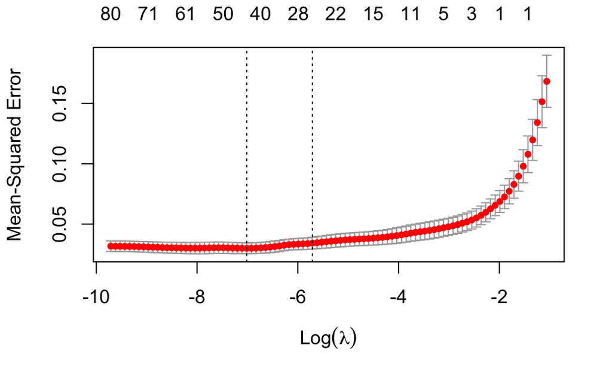

```r
plot(cv.out)
```

### PCR

The principle components regression command, `pcr`, returns both the CV errors and the adjusted CV errors. For the definition of adjusted CV used in `pcr`, check Sec 2.4 of [this paper](https://mevik.net/work/publications/MSEP_estimates.pdf).

```r
mypcr = pcr(Y ~ ., data= myData[-test.id, ], validation="CV")
CVerr = RMSEP(mypcr)$val[1, , ]
adjCVerr = RMSEP(mypcr)$val[2, , ]
best.ncomp = which.min(CVerr) - 1
best.ncomp
```

```
58 comps
      58
```

```r
if (best.ncomp==0) {
    Ytest.pred = mean(myData$Y[-test.id])
  } else {
    Ytest.pred = predict(mypcr, myData[test.id,], ncomp=best.ncomp)
  }

MSPE[7] = mean((Ytest.pred - myData$Y[test.id])^2)
```

Note that we have to subtract one from `which.min(CVerr)` since the 1st column of the CV table corresponds to the CV error with zero components (i.e., the model with just the intercept) and the k-th column of the CV table corresponds to (k-1) components.

The prediction function does not seem to work when `best.ncomp = 0`. So we have to handle that case separately.

```r
MSPE
```

```
         Full         R_min         R_1se         L_min
0.03020626894 0.02406011858 0.02963898735 0.02522686497
        L_1se       L_Refit           PCR
0.03122833021 0.02948834068 0.02248249006
```